# Unit 1: Intro to Statistics and R

# Learning Goals

- Understand the major goals of statistics.
- Distinguish between a sample and a population.
- Distinguish between an estimate and a parameter.
- Identify why estimates from samples may deviate from the parameters of populations.
- Identify the properties of a good sample.
- Describe the differences between observational and experimental studies.
- Identify whether a variable is numeric or categorical (and subtypes).
- Distinguish between sampling bias and sampling error.
- Distinguish between accuracy and precision and how these terms relate to sampling bias and sampling error.
- Understand the distinction between the term “population” in a statistical and a biological context.
- Distinguish between correlation and causation.

# 1.1. Populations, samples, parameters and estimates

## What is statistics?

[figure not shown]

Tweet from someone I don’t know, but very on point, so thank you!

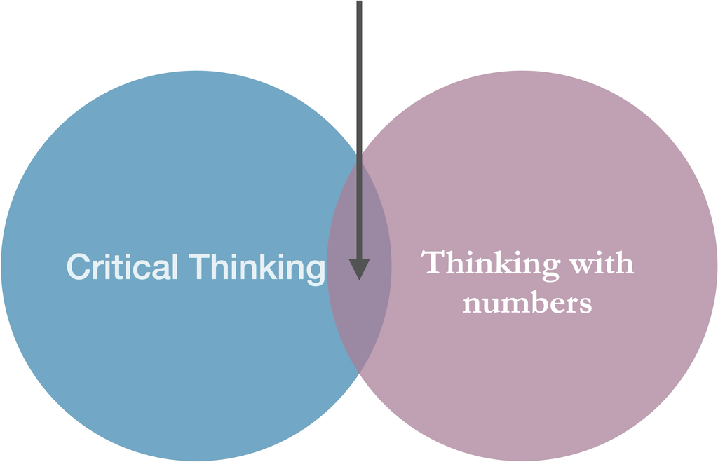

## Statistics deals with UNCERTAINTY

- Statistics are a quantitative technology for empirical science.
- A logic and methodology for the measurement of **uncertainty** and for an examination of that uncertainty.
- The key word here is **uncertainty**. Statistics becomes necessary when observations are **variable**.

## What is BIOstatistics?

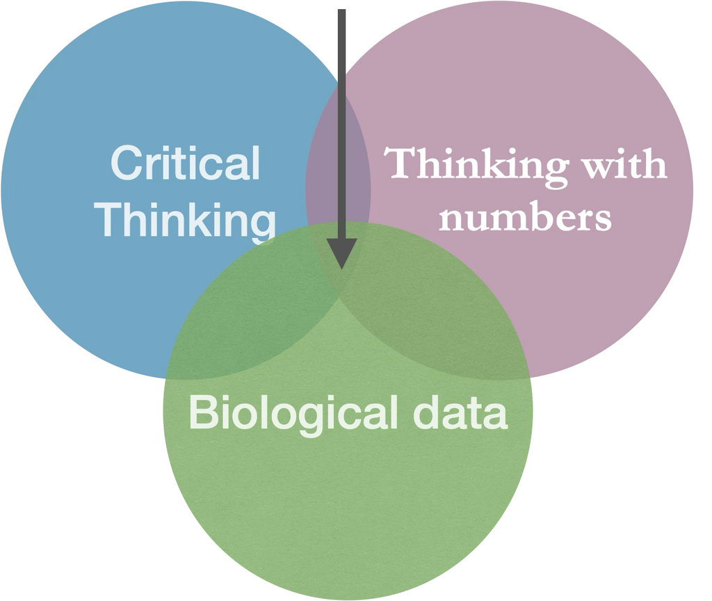

## Goals of statistics

Goal: learn about the world

[figure not shown]

From: imgflip.com/memegenerator

## The Central Obsession

- Question: How do we make inferences about the WORLD from our finite observations?
- Answer: Make models to account for the process of sampling and the associated hazards.

## Great but…

- New Challenge: Samples deviate from the populations by luck/chance (**sampling error**) or unrepresentative sampling (**sampling bias**)
- Solution:
  - **Estimate** the values of important parameters
  - Have **measures of uncertainty** for estimates
  - **Test hypotheses** about those parameters

## Biostatistics: Relevance

- What is the motivating biological question?
- What experiments can be done and/or data can be collected to address this question?
- Do results support an interesting conclusion?
- What are the shortcomings/limitations of statistical models and causal frameworks in the analysis?
- How do I best communicate my results (including estimates, visualizations, conclusions, and caveats)?

## Important distinctions

- Population (biological) x population (statistical)
- Populations vs. samples
- Parameters vs. estimates (statistic)

## Populations (Biology)

> In Biology | collection of interbreeding individuals of the same species that live in sufficient proximity that most mates are drawn from this collection of individuals. This mostly applies to animals and, to some extent, plants.

## Populations (statistics)

> In Statistics| the entire collection of individual units that a researcher is interested in. E.g. all women born in the US between 1990 and 200; all polar bears currently living in zoos; users of a certain social network in a certain age group; etc

## Parameters & Estimates (statistics)

A parameter is some property of the world, i.e., the “truth”

[figure not shown]

Decorative image. Poster from the show “The X-files”

## A population of starfish

- Parameters describe populations
- E.g. proportion of pink starfish among all starfish of a given species in a certain location

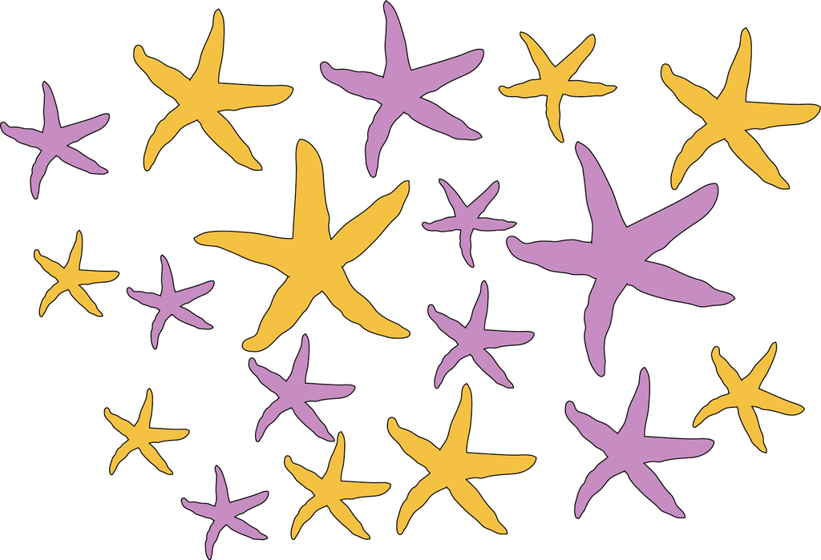

## A sample of starfish

- Estimates (statistics) approximate parameters as inferred from samples
- We estimate the proportion of pink as inferred from this sample and extrapolate to the population as an approximation.

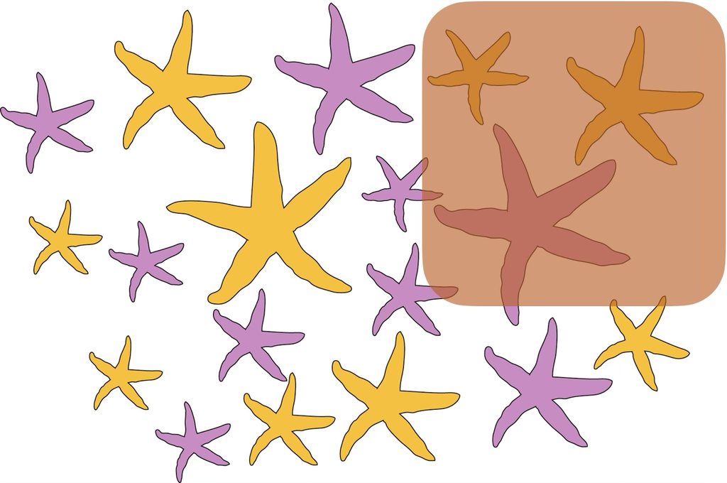

## In summary

**Parameters and populations**

- Parameters describe Populations
- Because we can’t sample an entire population, we usually don’t know parameters.

**Estimates and samples**

- But we can get a good sense of the parameters from estimates we make from samples.
- Estimates approximate parameters as inferred from Samples

# 1.2. Sampling: What could go wrong

## Properties of a good sample

Independent selection of individuals

- no influence of sampling one individual on other individuals that get sampled.

Random selection of individuals

- each member of a population has an equal and independent chance of being selected
- equality: probability of being selected reflects its representation in the population

Sufficiently large

- What is the point of each of these principles in terms of sampling error and bias and accuracy and precision?

## Random samples

Taking random samples is hard and requires effort

- Why are they important? Reduce sampling bias
- How to get a random sample (ideal):
- Carefully characterize a population and use computer code to select participants randomly.

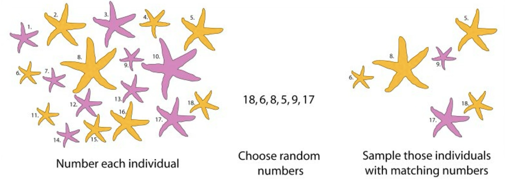

## Sampling bias

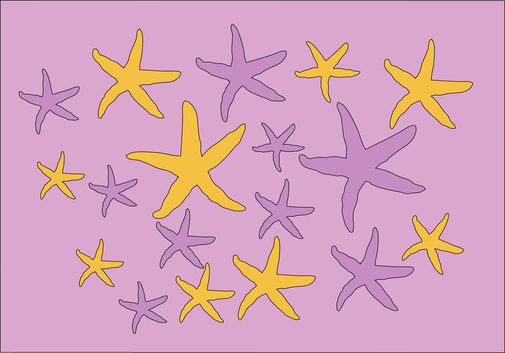

- This sample is biased. There is a higher proportion of orange stars than the population from which it was taken. Therefore, it is not a representative sample of the underlying population.

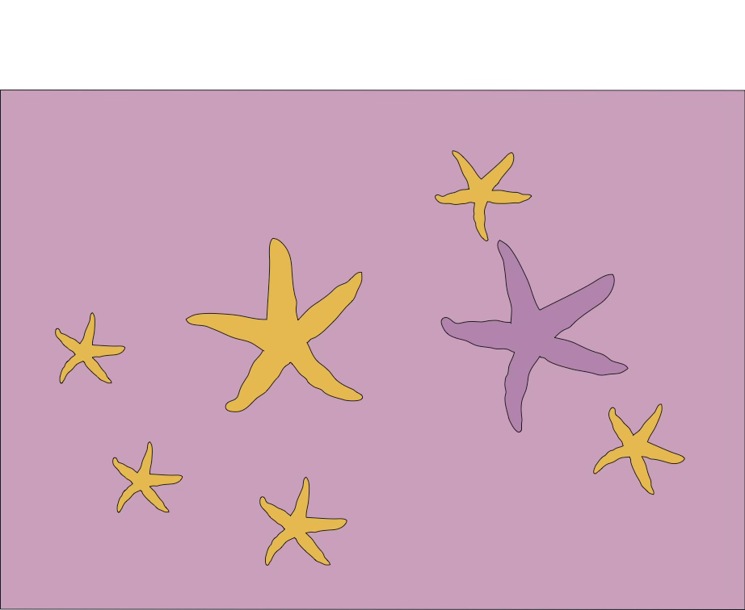

## Sampling bias case study

Sampling bias: Systematic difference between parameters & estimates.

[figure not shown]

[figure not shown]

Democrat Franklin Roosevelt

Case study: Polls in the 1936 US Election.

## 1936 Literary Digest poll

2.4 million responses to 10 million questionnaires , sent to people from telephone books and club lists.

## 1936 Literary Digest poll

**Hide the code**

```r
## | label: 1936-election
library(ggplot2)
ggplot(data.frame(Candidate = c("Landon", "Roosevelt"), support = 2.4 *
    c(0.57, 0.43)), aes(x = Candidate, y = support, fill = Candidate)) +
    geom_bar(stat = "identity", show.legend = FALSE) + bb_theme() +
    ylab(label = "support (millions of respondents)") + geom_hline(yintercept = seq(0,
    1.4, 0.5), color = "white") + coord_flip() + scale_y_continuous(expand = c(0,
    0)) + ggtitle(label = "1936 literary digest poll results")
```

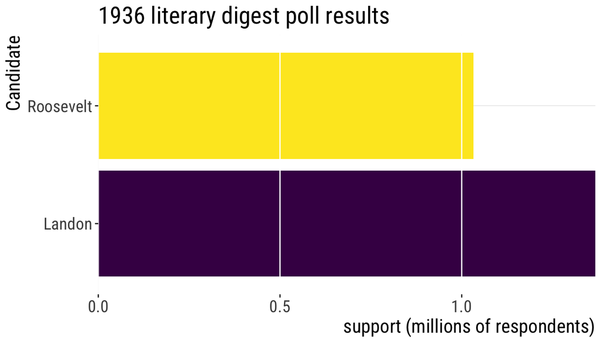

Figure made in R with code borrowed from Y. Brandvain

## Election: Roosevelt won in a landslide

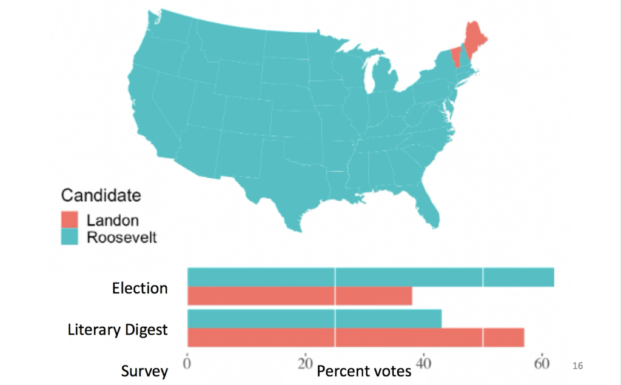

This plot was made in R (Credit: Y. Brandvain)

What do you think happened?

## Sampling Bias in the 1936 Polls!

- Questionnaire was more likely to reach rich people (who could afford phones & attend book clubs) than those with fewer means.
- Voting and party preference are correlated with wealth.
- Poorer people (underrepresented in the poll) supported Roosevelt, carrying him to victory.

## Sample of convenience

A sample of convenience is a collection of individuals that happen to be available at the time.

Other definitions<sup>1</sup>:

> A convenience sample is the one that is drawn from a source that is conveniently accessible to the researcher.

> A purposive sample is the one whose characteristics are defined for a purpose that is relevant to the study.

Problems:

- “In research, we therefore implicitly seek to generalize the findings from our sample to the entire population, present and future.”<sup>2</sup>
- low generalizability. What is true for your sample might not reflect what is true for the population.
- in practice, you can only generalize findings to the subpopulation from which the sample was taken from.
- sometimes, a sample of convenience is the best option researchers have (e.g. studies that extract data from national healthcare or insurance databases)
- It is rarely possible to draw a truly random sample from the population

This does not invalidate the studies in question. They can have high “internal validity”. The issue is with generalizing, i.e, its external validity.

[^1]: Andrade C (2021). The Inconvenient Truth About Convenience and Purposive Samples. Indian J Psychol Med, 43(1):86-88. DOI: 10.1177/0253717620977000
[^2]: Andrade C (2021). Indian J Psychol Med, 43(1):86-88. DOI: 10.1177/0253717620977000

## Volunteer bias

Volunteers for a study are likely to be different, on average, from the population. Also known as “self-selection” bias.

For example:

- Volunteers for sex studies are more likely to be open about sex.
- In surveys about sexual activity, gender biases answers in opposite directions.
- Volunteers for medical studies may be sicker than the general population.
- Animals that are caught may be slower or more docile than those that are not.
- The case we saw about the 1936 U.S. elections.

## Selection bias

[figure not shown]

## What about sampling error?

Sampling error: Chance deviations between estimates and the truth.

Even when you did NOTHING wrong.

Sampling error is the difference between the estimate and its true parameter value — and it can be quantified!

### Example of sampling error

**Hide the code**

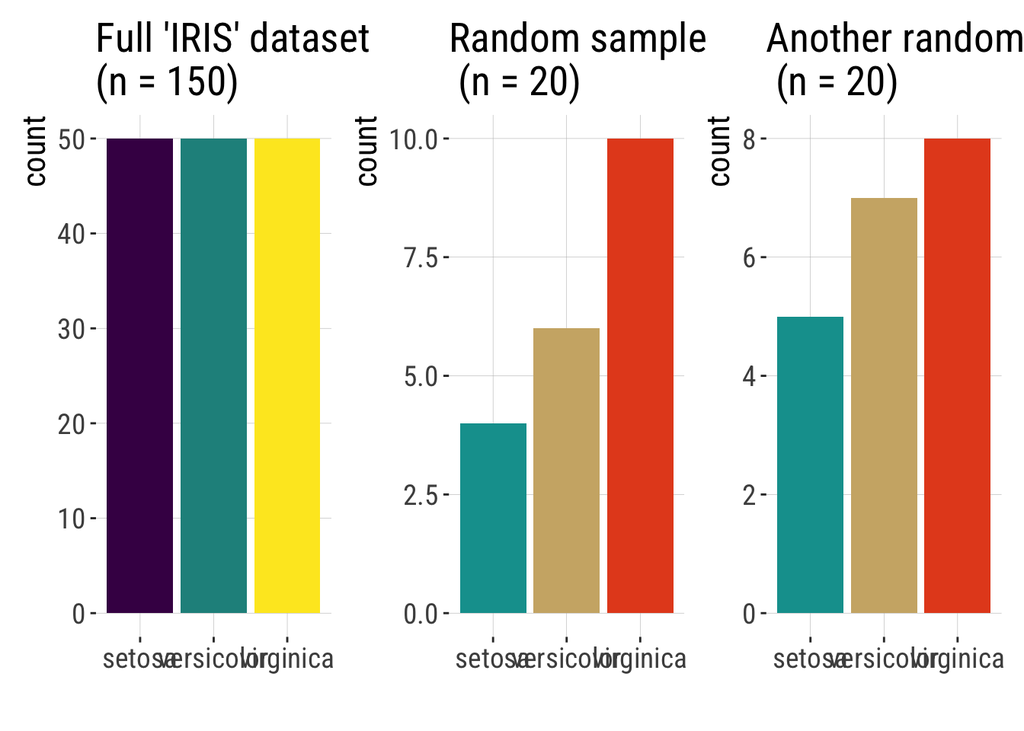

```r
library(tidyverse)
p1 <- iris |>
    ggplot(aes(x = Species, fill = Species)) + geom_bar() + bb_theme() +
    theme(legend.position = "none") + ggtitle("Full 'IRIS' dataset\n(n = 150)") +
    xlab("")
p2 <- iris |>
    sample_n(size = 20) |>
    ggplot(aes(x = Species, fill = Species)) + geom_bar() + scale_fill_manual(values = wesanderson::wes_palette("AsteroidCity1")) +
    bb_theme() + theme(legend.position = "none") + ggtitle("Random sample\n (n = 20)") +
    xlab("")
p3 <- iris |>
    sample_n(size = 20) |>
    ggplot(aes(x = Species, fill = Species)) + geom_bar() + scale_fill_manual(values = wesanderson::wes_palette("AsteroidCity1")) +
    bb_theme() + theme(legend.position = "none") + ggtitle("Another random sample\n (n = 20)") +
    xlab("")
library(patchwork)
p1 + p2 + p3
```

The iris data set gives the measurements (in cm) of the variables sepal length and width and petal length and width for 50 flowers from each of 3 species of iris. The species are *Iris setosa*, *Iris versicolor*, and *Iris virginica*.

## Sampling error declines with sample size

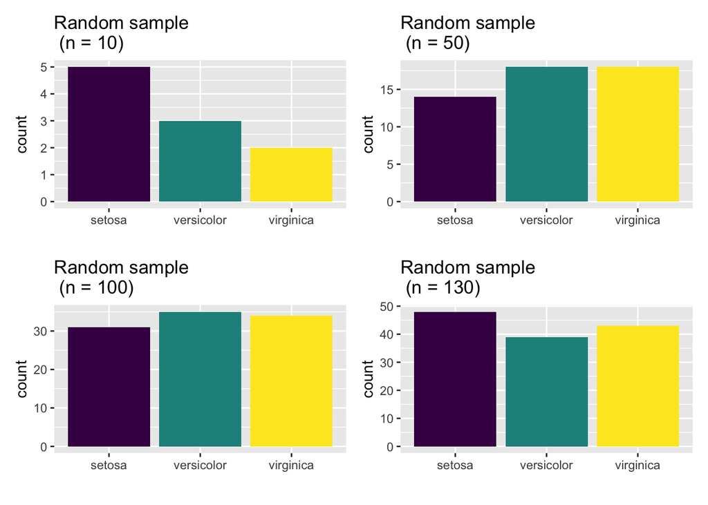

## Estimates are random variables

- Because an estimate is a random variable, the value of an estimate is influenced by chance.
- Therefore estimates will differ among random samples from the same population.

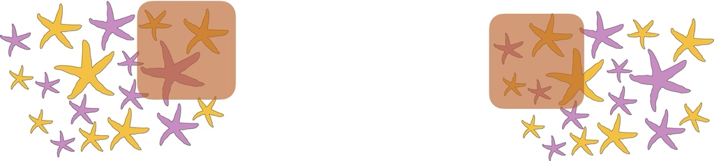

## How bias and sampling error affect estimates

**Sampling Bias**

- Systematic difference between estimates & parameters.
- Driven by bias in the sampling process (i.e., sample not random in relation to the population of interest), regarless of sample size.

**Sampling Error**

- Undirected deviation of estimates away from parameters.
- Driven by chance.
- Decreases with sample size.

## Goals of estimation

Accuracy (on average gets the correct answer)

Precision (gives a similar answer repeatedly)

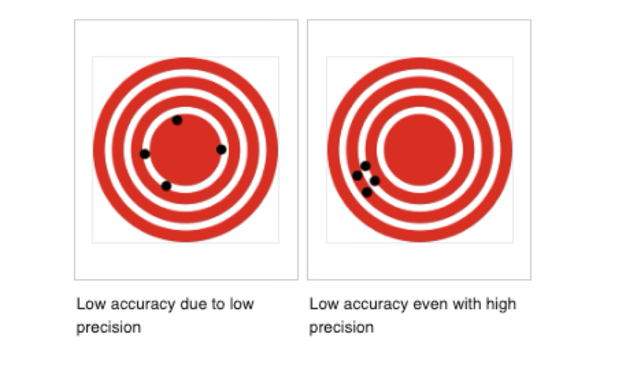

Image: Wikipedia Commons (public domain).

## Sampling error vs. bias

In this figure, the “X” is the population parameter. The circles are different estimates calculated from different samples taken from that population.

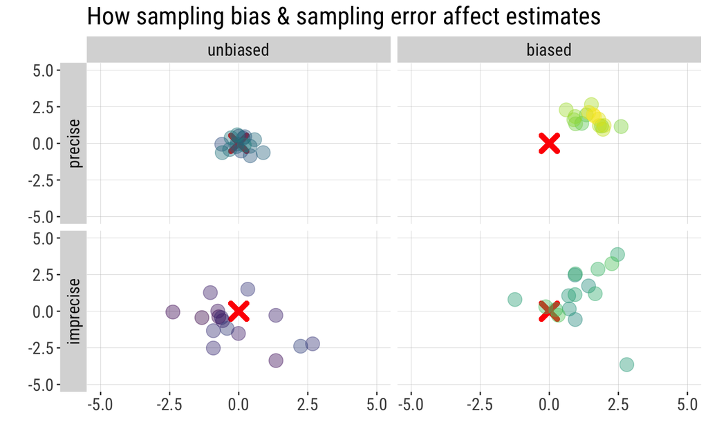

Figure made in R with code borrowed from Y. Brandvain

## Acknowledgments

- Yaniv Brandvain, Freeman & Company, and Michael Whitlock for some materials used here.